# phylo.ternary.plot

Nick Crouch

Apr 16 2019

There is an increasing box of tricks for display data on phylogenetic trees. However, it can be difficult to visualize lots of different values on the internal branches of trees. Here, I show *phylo.ternary.plot* – a function for summarizing (specificaly) three different sets of results on a phylogeny.

```r
source("phylo.ternary.plot.R")
```

The function, which you can download here, shows the results of analyses where the branch lengths of a phylogeny have been changed to represent a rate. Here, I will use two analyses from BayesTraits (for size and shape) and one from PAML (showing dN/dS). The function itself takes five arguments:

- `source.phy`: An object of class `phylo` corresponding to the base phylogeny
- `targetPhy1`: An object of class `phylo` corresponding to the output of an analysis
- `targetPhy2`: An object of class `phylo` corresponding to the output of an analysis
- `targetPhy3`: An object of class `phylo` corresponding to the output of an analysis
- `names`: A `character` vector giving the names of each `phylo` object.

The function requires a few packages

```r
  library(tricolore)
  library(ape)
  library(dplyr)
  library(grid)
  library(gridExtra)
  library(ggplot2)
  library(ggtree)

source("phylo.ternary.plot.R")
```

Now let’s load the phylogenetic data

```r
 base.phy <- read.nexus("coracii.nex")
 targetPhy1 <- read.nexus("summaryPaml.nex")
 targetPhy2 <- read.nexus("summaryShapeTree.nex")
 targetPhy3 <- read.nexus("summarySizeTree.nex")

 # and their names
 names <- c("dN/dS", "rateShapeEvol", "rateSizeEvol")
```

For comparison, let’s see what each of these trees look like when plotted individually

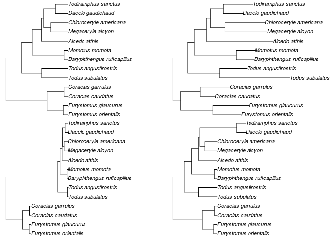

```r
par(mfrow=c(2,2))
plot(base.phy, no.margin = TRUE)
plot(targetPhy1, no.margin = TRUE)
plot(targetPhy2, no.margin = TRUE)
plot(targetPhy3, no.margin = TRUE)
```

Now let’s look like when all three are visualized on the same phylogeny

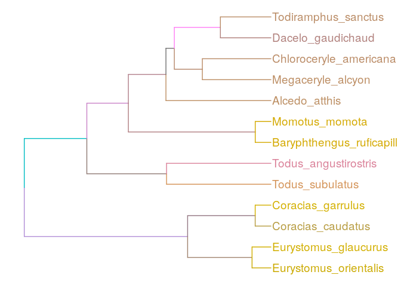

```r
res <- phylo.ternary.plot(source.phy = base.phy,
                   targetPhy1 = targetPhy1,
                   targetPhy2 = targetPhy2,
                   targetPhy3 = targetPhy3,
                   names = names)

res[[1]]
```

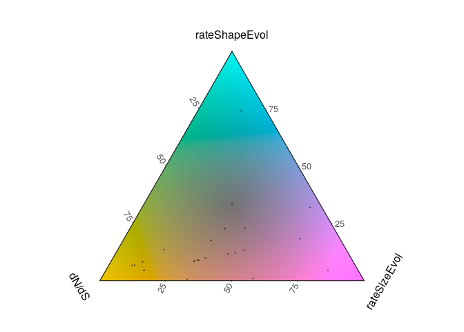

```r
print(res[[2]])
```

The individual points in the legend correspond to individual branches on the phylogeny. You can see the one highly blue branch corresponds to the phylogeny with the high rate of shape evolution. It’s a fairly specific way of showing data on a phylogeny, but i think it has potential utility.